# Analyzing QUBO solutions

```python
avg_cost_df = analyzer._average_cost()
print("Average cost for all bitstrings per solution:")
print(avg_cost_df)

print('------------------------------------------------')
avg_cost_df = analyzer._average_cost(0.5)
print("Average cost for top 50% bitstrings per solution:")
print(avg_cost_df)

print('------------------------------------------------')
avg_cost_df = analyzer._average_cost(0.1)
print("Average cost for top 10% bitstrings per solution:")
print(avg_cost_df)
print('------------------------------------------------')
avg_cost_df = analyzer._average_cost(0.01)
print("Average cost for top 1% bitstrings per solution:")
print(avg_cost_df)
```

avg_cost_df = analyzer._average_cost() print("Average cost for all bitstrings per solution:") print(avg_cost_df) print('------------------------------------------------') avg_cost_df = analyzer._average_cost(0.5) print("Average cost for top 50% bitstrings per solution:") print(avg_cost_df) print('------------------------------------------------') avg_cost_df = analyzer._average_cost(0.1) print("Average cost for top 10% bitstrings per solution:") print(avg_cost_df) print('------------------------------------------------') avg_cost_df = analyzer._average_cost(0.01) print("Average cost for top 1% bitstrings per solution:") print(avg_cost_df)

```
Average cost for all bitstrings per solution:
  labels  average cost  bitstrings considered
0   sol1         8.375                      8
1   sol2         8.375                      8
------------------------------------------------
Average cost for top 50% bitstrings per solution:
  labels  average cost  bitstrings considered
0   sol1           4.5                      4
1   sol2           5.6                      5
------------------------------------------------
Average cost for top 10% bitstrings per solution:
  labels  average cost  bitstrings considered
0   sol1           2.0                      1
1   sol2           2.0                      1
------------------------------------------------
Average cost for top 1% bitstrings per solution:
  labels  average cost  bitstrings considered
0   sol1           2.0                      1
1   sol2           2.0                      1
```

```python
best_bit_df = analyzer._best_bitstrings()
print("Best bitstring per solution:")
print(best_bit_df)
```

best_bit_df = analyzer._best_bitstrings() print("Best bitstring per solution:") print(best_bit_df)

```
Best bitstring per solution:
  labels bitstrings  costs  counts  probs
0   sol1        011    2.0      16   0.16
1   sol2        011    2.0      10   0.10
```

```python
df_with_gaps = analyzer.calculate_gaps(opt_cost=10)
print("DataFrame after calculating gaps (opt_cost=10):")
print(df_with_gaps)
```

df_with_gaps = analyzer.calculate_gaps(opt_cost=10) print("DataFrame after calculating gaps (opt_cost=10):") print(df_with_gaps)

```
DataFrame after calculating gaps (opt_cost=10):
   labels bitstrings  costs  counts  probs  gaps
0    sol1        000   12.0      11   0.11   0.2
1    sol1        001    7.0       9   0.09   0.3
2    sol1        010   13.0       9   0.09   0.3
3    sol1        011    2.0      16   0.16   0.8
4    sol1        100    4.0      12   0.12   0.6
5    sol1        101   10.0      13   0.13   0.0
6    sol1        110    5.0      15   0.15   0.5
7    sol1        111   14.0      15   0.15   0.4
8    sol2        000   12.0      17   0.17   0.2
9    sol2        001    7.0      13   0.13   0.3
10   sol2        010   13.0      10   0.10   0.3
11   sol2        011    2.0      10   0.10   0.8
12   sol2        100    4.0       8   0.08   0.6
13   sol2        101   10.0      12   0.12   0.0
14   sol2        110    5.0      10   0.10   0.5
15   sol2        111   14.0      20   0.20   0.4
```

```python
# Filter by percentage: keep top 10% (lowest cost) bitstrings per solution
filtered_percent_df = analyzer._filter_by_percentage(column="gaps",top_percent=0.1)
print("DataFrame after filtering by top 10% (by cost):")
print(filtered_percent_df)
```

# Filter by percentage: keep top 10% (lowest cost) bitstrings per solution filtered_percent_df = analyzer._filter_by_percentage(column="gaps",top_percent=0.1) print("DataFrame after filtering by top 10% (by cost):") print(filtered_percent_df)

```
DataFrame after filtering by top 10% (by cost):
  labels bitstrings  costs  counts  probs  gaps
0   sol1        101   10.0      13   0.13   0.0
1   sol2        101   10.0      12   0.12   0.0
```

```python
plot1 = analyzer.plot(
    x_axis="bitstrings",
    y_axis="probs",
    sort_by="probs",
    sort_order="ascending",
    context="notebook"
)
```

plot1 = analyzer.plot( x_axis="bitstrings", y_axis="probs", sort_by="probs", sort_order="ascending", context="notebook" )

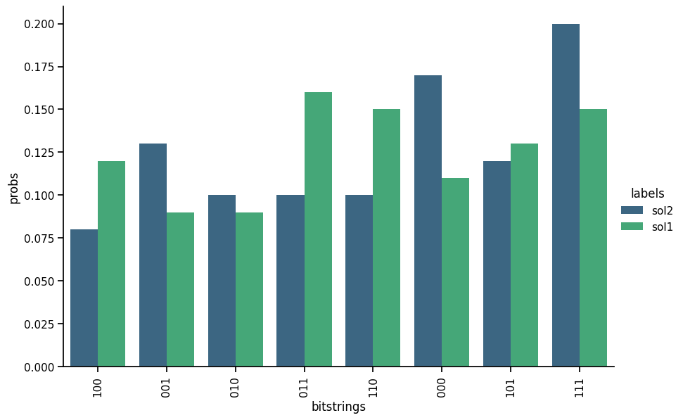

```python
plot2 = analyzer.plot(
    x_axis="costs",
    y_axis="probs",
    sort_by="costs",
    sort_order="ascending",
    context="notebook"
)
```

plot2 = analyzer.plot( x_axis="costs", y_axis="probs", sort_by="costs", sort_order="ascending", context="notebook" )

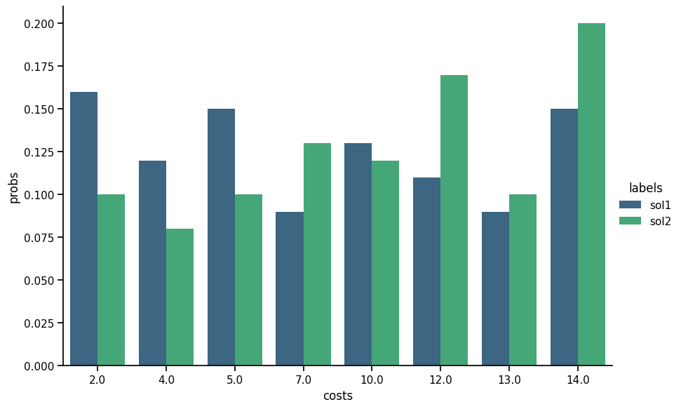

```python
plot2 = analyzer.plot(
    x_axis="costs",
    y_axis="probs",
    sort_by="costs",
    sort_order="ascending",
    probability_threshold=0.1,
    context="notebook"
)
```

plot2 = analyzer.plot( x_axis="costs", y_axis="probs", sort_by="costs", sort_order="ascending", probability_threshold=0.1, context="notebook" )

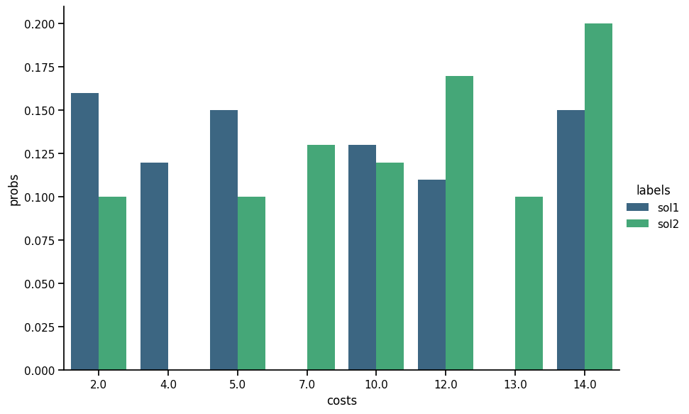

```python
plot2 = analyzer.plot(
    x_axis="costs",
    y_axis="probs",
    sort_by="costs",
    sort_order="ascending",
    cost_threshold=11,
    context="notebook"
)
```

plot2 = analyzer.plot( x_axis="costs", y_axis="probs", sort_by="costs", sort_order="ascending", cost_threshold=11, context="notebook" )

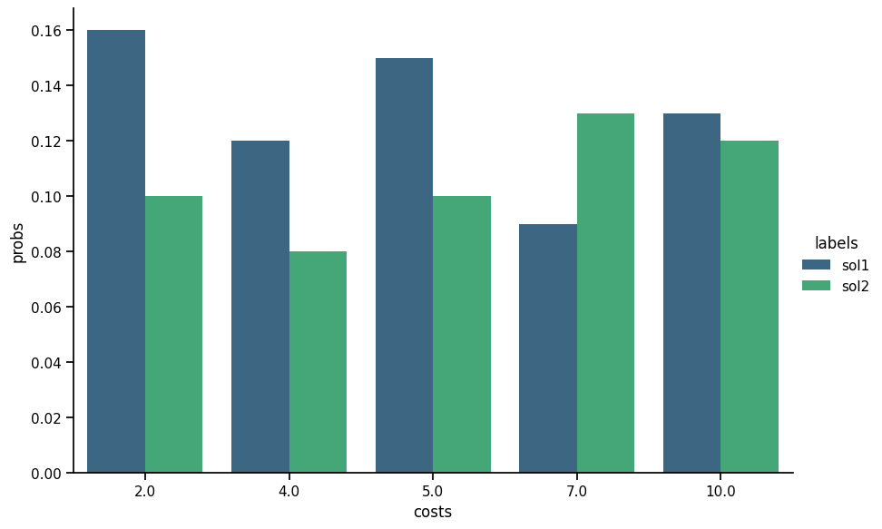

```python
plot2 = analyzer.plot(
    x_axis="costs",
    y_axis="probs",
    sort_by="costs",
    sort_order="ascending",
    top_percent=0.1,
    context="notebook"
)
```

plot2 = analyzer.plot( x_axis="costs", y_axis="probs", sort_by="costs", sort_order="ascending", top_percent=0.1, context="notebook" )

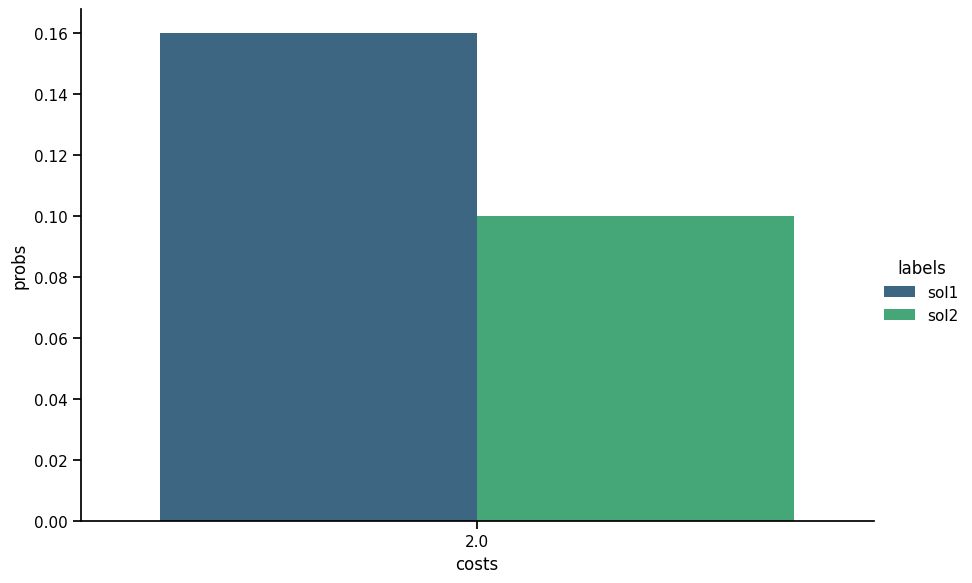

```python
plot2 = analyzer.plot(
    x_axis="costs",
    y_axis="probs",
    sort_by="costs",
    sort_order="ascending",
    labels=['sol1'],
    context="notebook"
)
```

plot2 = analyzer.plot( x_axis="costs", y_axis="probs", sort_by="costs", sort_order="ascending", labels=['sol1'], context="notebook" )

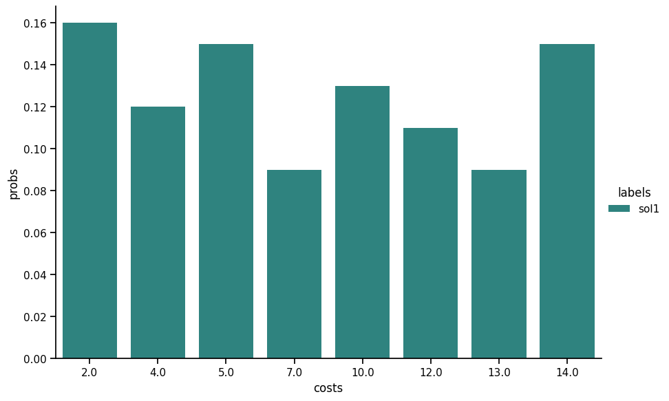

```python
# Create a new solution with different bitstrings and costs
bitstrings = torch.randint(0, 2, (5, bit_length), dtype=torch.int8)
bitstrings,counts=bitstrings.unique(dim=0,return_counts=True)
costs = torch.randint(1, 20, (len(bitstrings),), dtype=linalg.dtype())
solution3 = Solution(bitstrings, costs, counts)
solution3.compute_probabilities()

# Create the analyzer with our three solutions
analyzer = Analyzer([solution1, solution2, solution3], labels=["sol1", "sol2", "sol3"])
```

# Create a new solution with different bitstrings and costs bitstrings = torch.randint(0, 2, (5, bit_length), dtype=torch.int8) bitstrings,counts=bitstrings.unique(dim=0,return_counts=True) costs = torch.randint(1, 20, (len(bitstrings),), dtype=linalg.dtype()) solution3 = Solution(bitstrings, costs, counts) solution3.compute_probabilities() # Create the analyzer with our three solutions analyzer = Analyzer([solution1, solution2, solution3], labels=["sol1", "sol2", "sol3"])

```python
# Compare the solutions
analyzer.compare_qubo_solutions(["sol1", "sol3"])
print("\n -------------------------------------- \n")
analyzer.compare_qubo_solutions(["sol1", "sol2"])
```

# Compare the solutions analyzer.compare_qubo_solutions(["sol1", "sol3"]) print("\n -------------------------------------- \n") analyzer.compare_qubo_solutions(["sol1", "sol2"])

```
Comparing two lists of bitstrings:
1. sol1: 8 bitstrings (8 unique strings)
2. sol3: 4 bitstrings (4 unique strings)

Bitstrings in sol1 not present in sol3:
- 001
- 111
- 101
- 110

Ratio of different bitstrings: 4/8 = 50%

 --------------------------------------

Comparing two lists of bitstrings:
1. sol1: 8 bitstrings (8 unique strings)
2. sol2: 8 bitstrings (8 unique strings)

The lists contain exactly the same bitstrings.
```